# 1. Fundamentals of Data Analysis

## Outline

- Pandas Basics
  - Input and Output
  - Examining DataFrame
  - Indexing and Slicing
  - Conditional
  - Changing Data Type
  - Sort
  - Apply and Applymap
  - Plot
  - Exercises and Solutions

## Pandas Basics

這一節會教大家如何使用 Pandas 做基本的資料處理，包括存取檔案、檢查數據表格、選取特定資料、資料排序、資料轉換、以及繪製圖表。

```python
import pandas as pd
import numpy as np
import matplotlib.pyplot as plt

print(pd.__version__)
```

```
0.23.4
```

```python
from pathlib import Path
data_folder = Path("../data/")
```

## Input and Output

Pandas 提供許多常見類型資料的輸入和輸出，如 csv、json、excel、html、sql、pickle等。

更多關於 Pandas IO Tools:  
https://pandas.pydata.org/pandas-docs/stable/io.html

```python
news = pd.read_csv(data_folder / "news.csv")
```

```python
polls = pd.read_json(data_folder / "polls.json")
```

#### pandas.DataFrame.to_csv

```python
polls.to_csv(data_folder / "polls.csv", index=False)
```

#### Pickle (Serialization)

```python
polls.to_pickle(data_folder / "polls.p")
polls_pickle = pd.read_pickle(data_folder / "polls.p")
```

## Examining DataFrame

讀進來資料後，可以使用 `.info()` 看數據資料型別、`.head()` 選出前幾筆資料、`.tail()` 選出最後幾筆資料、`.columns` 來看欄位名稱、`.index` 來看索引名稱。

```python
news.info()
```

```
<class 'pandas.core.frame.DataFrame'>
RangeIndex: 120 entries, 0 to 119
Data columns (total 5 columns):
title       120 non-null object
content     120 non-null object
time        120 non-null object
provider    120 non-null object
url         120 non-null object
dtypes: object(5)
memory usage: 4.8+ KB
```

```python
news.head()
```

|  | title | content | time | provider | url |
| --- | --- | --- | --- | --- | --- |
| 0 | 「把25年前韓國瑜打人事件當英雄看」陳水扁批：吳敦義「災難政治學」的表現 | 國民黨主席吳敦義日前提到高雄市長候選人韓國瑜過去打陳水扁，表示「很認同跟敬佩」並形容「允文允... | 2018-10-22 12:16:02+08:00 | 風傳媒 | https://tw.news.yahoo.com/把25年前韓國瑜打人事件當英雄看-陳水扁... |
| 1 | 【Yahoo論壇／林青弘】柯文哲是否一再說謊？ | 柯文哲市長在台北市北投區七星公園造勢，行動競選總部的大卡車開進公園，違規臨停。競辦被開罰六張... | 2018-10-22 14:00:26+08:00 | 林青弘 | https://tw.news.yahoo.com/【yahoo論壇%EF%BC%8F林青弘... |
| 2 | 【Yahoo論壇】民進黨誰最怕陳其邁落選？ | 讀者投書：廖念漢（現任奇策盟文宣部主任、曾任海巡署專聘講師）\n 《長平之戰》是戰國時代最戲... | 2018-10-22 13:57:44+08:00 | 讀者投書 | https://tw.news.yahoo.com/【yahoo論壇】民進黨誰最怕陳其邁落選... |
| 3 | 抽中籤王 韓國瑜車隊掃街 民眾路邊紛比讚 | 國民黨高雄市長候選人韓國瑜聲勢上漲，又抽中一號籤王，心情相當興奮，立即展開掃街拜，經過的地方... | 2018-10-22 13:32:00+08:00 | EBC東森新聞 | https://tw.news.yahoo.com/抽中籤王-韓國瑜車隊掃街-民眾路邊紛比讚... |
| 4 | 百年土地公上香祈福 陳學聖提五不原則 | 【綜合報導】普悠瑪列車出軌意外舉國震驚如同國難，令社會大眾、競選團隊及陳學聖本人都感到十分沉... | 2018-10-22 13:17:44+08:00 | 民眾日報 | https://tw.news.yahoo.com/百年土地公上香祈福-陳學聖提五不原則-0... |

```python
news.tail(2)
```

|  | title | content | time | provider | url |
| --- | --- | --- | --- | --- | --- |
| 118 | 林姿妙請韓國瑜站台 「韓流」氣勢壓過主角 | 宜蘭縣長選情廝殺激烈，國民黨候選人林姿妙，請來黨內人氣王韓國瑜、蔣萬安助陣，不過韓國瑜一出場... | 2018-10-20 19:42:14+08:00 | 民視 | https://tw.news.yahoo.com/林姿妙請韓國瑜站台-韓流-氣勢壓過主角-... |
| 119 | 鄭進一南下高雄 力挺韓國瑜 (圖) | 資深音樂人鄭進一（左）20日南下高雄為國民黨高雄市長參選人韓國瑜（中）站台，鄭進一說，從電視... | 2018-10-20 19:14:32+08:00 | 中央社 | https://tw.news.yahoo.com/鄭進-南下高雄-力挺韓國瑜-圖-1114... |

```python
polls.info()
```

```
<class 'pandas.core.frame.DataFrame'>
RangeIndex: 152 entries, 0 to 151
Data columns (total 5 columns):
支持率     152 non-null object
時間      152 non-null object
有效樣本    152 non-null object
機構      152 non-null object
訪問主題    152 non-null object
dtypes: object(5)
memory usage: 6.0+ KB
```

```python
polls.columns
```

```
Index(['支持率', '時間', '有效樣本', '機構', '訪問主題'], dtype='object')
```

```python
polls.index
```

```
RangeIndex(start=0, stop=152, step=1)
```

## Indexing and Slicing

可以選出特定部分的數據表格和欄位。

```python
# df[column]
news['title']
```

```
0      「把25年前韓國瑜打人事件當英雄看」陳水扁批：吳敦義「災難政治學」的表現
1                   【Yahoo論壇／林青弘】柯文哲是否一再說謊？
2                     【Yahoo論壇】民進黨誰最怕陳其邁落選？
3                      抽中籤王 韓國瑜車隊掃街 民眾路邊紛比讚
4                        百年土地公上香祈福 陳學聖提五不原則
5                     侯友宜客家後援總會成立！誓言拓展客文化據點
6             選不過別人就栽贓韓國瑜是黑道？ 孫大千：綠營比小學生還幼稚
7                    普悠瑪翻覆釀百死傷 韓國瑜「這舉動」網友狂讚
8                     黃偉哲競選總部開幕 蔡英文、賴清德合體造勢
9                         讚韓國瑜打扁 扁怒批吳敦義得意囂張
10               重提曾被韓國瑜推倒住院 扁轟：還真以為高雄市長贏定了
11               高雄反併吞大遊行 陳其邁：這三件事，讓國際都關注台灣
12                       白狼現身侯友宜鶯歌場 侯辦急劃清關係
13                      社評：柯文哲的「台灣商品論」想說給誰聽
14                    韓流在全台發威 韓國瑜和民眾高唱中華民國頌
```

[output cut: 47 more lines]

```python
# df.column
news.title
```

```
0      「把25年前韓國瑜打人事件當英雄看」陳水扁批：吳敦義「災難政治學」的表現
1                   【Yahoo論壇／林青弘】柯文哲是否一再說謊？
2                     【Yahoo論壇】民進黨誰最怕陳其邁落選？
3                      抽中籤王 韓國瑜車隊掃街 民眾路邊紛比讚
4                        百年土地公上香祈福 陳學聖提五不原則
5                     侯友宜客家後援總會成立！誓言拓展客文化據點
6             選不過別人就栽贓韓國瑜是黑道？ 孫大千：綠營比小學生還幼稚
7                    普悠瑪翻覆釀百死傷 韓國瑜「這舉動」網友狂讚
8                     黃偉哲競選總部開幕 蔡英文、賴清德合體造勢
9                         讚韓國瑜打扁 扁怒批吳敦義得意囂張
10               重提曾被韓國瑜推倒住院 扁轟：還真以為高雄市長贏定了
11               高雄反併吞大遊行 陳其邁：這三件事，讓國際都關注台灣
12                       白狼現身侯友宜鶯歌場 侯辦急劃清關係
13                      社評：柯文哲的「台灣商品論」想說給誰聽
14                    韓流在全台發威 韓國瑜和民眾高唱中華民國頌
```

[output cut: 47 more lines]

```python
# df.loc[row_name, column_name]
polls.loc[10, '支持率']
```

```
{'林佳龍': '40.0%', '盧秀燕': '34.6%', '其他': '25.4%'}
```

```python
# df.iloc[row_number, column_number]
polls.iloc[10, 0]
```

```
{'林佳龍': '40.0%', '盧秀燕': '34.6%', '其他': '25.4%'}
```

```python
# use : to select a range
polls.iloc[0:3, 1:4]
```

|  | 時間 | 有效樣本 | 機構 |
| --- | --- | --- | --- |
| 0 | 2018/10/22 | 1077 | 旺旺中時 |
| 1 | 2018/10/19 | 1026 | TVBS |
| 2 | 2018/10/18 | 1075 | 信傳媒 |

```python
polls.iloc[1:4, :]
```

|  | 支持率 | 時間 | 有效樣本 | 機構 | 訪問主題 |
| --- | --- | --- | --- | --- | --- |
| 1 | {'其他': '20.0%', '蘇貞昌': '30.0%', '侯友宜': '50.0%'} | 2018/10/19 | 1026 | TVBS | 新北市長當選人 |
| 2 | {'魏明谷': '34.5%', '黃文玲': '4.8%', '其他': '27.4%',... | 2018/10/18 | 1075 | 信傳媒 | 彰化縣長當選人 |
| 3 | {'韓國瑜': '42.0%', '陳其邁': '35.0%', '其他': '23.0%'} | 2018/10/17 | 1009 | TVBS | 高雄市長當選人 |

```python
# use list to select a multiple items
polls.loc[[1,5,2], ['機構','時間']]
```

|  | 機構 | 時間 |
| --- | --- | --- |
| 1 | TVBS | 2018/10/19 |
| 5 | ETtoday 東森新聞雲 | 2018/10/15 |
| 2 | 信傳媒 | 2018/10/18 |

## Conditional

可以選出滿足特定條件的數據表格。

```python
polls['機構'] == 'TVBS'
```

```
0      False
1       True
2      False
3       True
4      False
5      False
6       True
7      False
8       True
9       True
10     False
11     False
12     False
13     False
14     False
```

[output cut: 47 more lines]

```python
polls[polls['機構'] == 'TVBS']
```

|  | 支持率 | 時間 | 有效樣本 | 機構 | 訪問主題 |
| --- | --- | --- | --- | --- | --- |
| 1 | {'其他': '20.0%', '蘇貞昌': '30.0%', '侯友宜': '50.0%'} | 2018/10/19 | 1026 | TVBS | 新北市長當選人 |
| 3 | {'韓國瑜': '42.0%', '陳其邁': '35.0%', '其他': '23.0%'} | 2018/10/17 | 1009 | TVBS | 高雄市長當選人 |
| 6 | {'蕭淑麗': '15.0%', '黃敏惠': '35.0%', '其他': '21.0%'... | 2018/10/15 | 803 | TVBS | 嘉義市長當選人 |
| 8 | {'饒慶鈴': '40.0%', '鄺麗貞': '5.0%', '其他': '24.0%',... | 2018/10/11 | 985 | TVBS | 台東縣長當選人 |
| 9 | {'林姿妙': '47.0%', '陳歐珀': '19.0%', '其他': '34.0%'} | 2018/10/09 | 830 | TVBS | 宜蘭縣長當選人 |
| 39 | {'柯文哲': '37.0%', '姚文智': '11.0%', '丁守中': '32.0%... | 2018/09/17 | 1001 | TVBS | 台北市長當選人 |
| 41 | {'其他': '20.0%', '蘇貞昌': '32.0%', '侯友宜': '48.0%'} | 2018/09/17 | 1011 | TVBS | 新北市長當選人 |
| 42 | {'楊麗環': '6.0%', '陳學聖': '17.0%', '其他': '24.0%',... | 2018/09/17 | 801 | TVBS | 桃園市長當選人 |
| 43 | {'林佳龍': '35.0%', '盧秀燕': '38.0%', '其他': '27.0%'} | 2018/09/17 | 1015 | TVBS | 台中市長當選人 |
| 44 | {'林義豐': '13.0%', '黃偉哲': '33.0%', '其他': '40.0%'... | 2018/09/17 | 859 | TVBS | 台南市長當選人 |
| 45 | {'韓國瑜': '35.0%', '陳其邁': '39.0%', '其他': '26.0%'} | 2018/09/17 | 1019 | TVBS | 高雄市長當選人 |
| 55 | {'徐欣瑩': '28.0%', '楊文科': '25.0%', '其他': '34.0%'... | 2018/08/31 | 1068 | TVBS | 新竹縣長當選人 |
| 68 | {'柯文哲': '40.0%', '姚文智': '11.0%', '丁守中': '30.0%... | 2018/07/24 | 870 | TVBS | 台北市長當選人 |
| 69 | {'其他': '23.0%', '蘇貞昌': '29.0%', '侯友宜': '48.0%'} | 2018/07/24 | 1030 | TVBS | 新北市長當選人 |
| 70 | {'陳學聖': '20.0%', '其他': '24.0%', '鄭文燦': '56.0%'} | 2018/07/24 | 803 | TVBS | 桃園市長當選人 |
| 71 | {'林佳龍': '33.0%', '盧秀燕': '39.0%', '其他': '28.0%'} | 2018/07/24 | 1077 | TVBS | 台中市長當選人 |
| 72 | {'林義豐': '7.0%', '黃偉哲': '41.0%', '其他': '37.0%',... | 2018/07/24 | 833 | TVBS | 台南市長當選人 |
| 73 | {'韓國瑜': '32.0%', '陳其邁': '40.0%', '其他': '28.0%'} | 2018/07/24 | 1012 | TVBS | 高雄市長當選人 |
| 85 | {'林佳龍': '33.0%', '盧秀燕': '39.7%', '其他': '27.3%'} | 2018/06/29 | 2520 | TVBS | 台中市長當選人 |
| 86 | {'徐欣瑩': '27.0%', '楊文科': '20.0%', '其他': '21.0%'... | 2018/06/29 | 1024 | TVBS | 新竹縣長當選人 |
| 88 | {'其他': '21.0%', '蘇貞昌': '31.0%', '侯友宜': '48.0%'} | 2018/06/26 | 907 | TVBS | 新北市長當選人 |
| 90 | {'陳學聖': '21.0%', '其他': '18.0%', '鄭文燦': '61.0%'} | 2018/06/23 | 853 | TVBS | 桃園市長當選人 |
| 106 | {'柯文哲': '31.0%', '姚文智': '13.0%', '丁守中': '33.0%... | 2018/05/31 | 1195 | TVBS | 台北市長當選人 |
| 121 | {'其他': '28.0%', '蘇貞昌': '32.0%', '侯友宜': '40.0%'} | 2018/04/12 | 957 | TVBS | 新北市長當選人 |
| 147 | {'其他': '13.0%', '蘇貞昌': '39.0%', '侯友宜': '48.0%'} | 2017/12/06 | 897 | TVBS | 新北市長當選人 |
| 150 | {'韓國瑜': '31.0%', '陳其邁': '59.0%', '其他': '10.0%'} | 2017/08/15 | 890 | TVBS | 高雄市長當選人 |
| 151 | {'林姿妙': '57.0%', '陳歐珀': '23.0%', '其他': '20.0%'} | 2017/07/19 | 811 | TVBS | 宜蘭縣長當選人 |

## Changing Data Type

可以將資料轉成適當的資料型別。

```python
polls.info()
```

```
<class 'pandas.core.frame.DataFrame'>
RangeIndex: 152 entries, 0 to 151
Data columns (total 5 columns):
支持率     152 non-null object
時間      152 non-null object
有效樣本    152 non-null object
機構      152 non-null object
訪問主題    152 non-null object
dtypes: object(5)
memory usage: 6.0+ KB
```

```python
polls['有效樣本'] = pd.to_numeric(polls['有效樣本'], errors='coerce')
polls.info()
```

```
<class 'pandas.core.frame.DataFrame'>
RangeIndex: 152 entries, 0 to 151
Data columns (total 5 columns):
支持率     152 non-null object
時間      152 non-null object
有效樣本    149 non-null float64
機構      152 non-null object
訪問主題    152 non-null object
dtypes: float64(1), object(4)
memory usage: 6.0+ KB
```

```python
polls[polls['有效樣本'] > 1000]
```

|  | 支持率 | 時間 | 有效樣本 | 機構 | 訪問主題 |
| --- | --- | --- | --- | --- | --- |
| 0 | {'其他': '19.9%', '蘇貞昌': '31.0%', '侯友宜': '49.1%'} | 2018/10/22 | 1077.0 | 旺旺中時 | 新北市長當選人 |
| 1 | {'其他': '20.0%', '蘇貞昌': '30.0%', '侯友宜': '50.0%'} | 2018/10/19 | 1026.0 | TVBS | 新北市長當選人 |
| 2 | {'魏明谷': '34.5%', '黃文玲': '4.8%', '其他': '27.4%',... | 2018/10/18 | 1075.0 | 信傳媒 | 彰化縣長當選人 |
| 3 | {'韓國瑜': '42.0%', '陳其邁': '35.0%', '其他': '23.0%'} | 2018/10/17 | 1009.0 | TVBS | 高雄市長當選人 |
| 4 | {'柯文哲': '37.5%', '姚文智': '11.3%', '丁守中': '25.0%... | 2018/10/15 | 1070.0 | 美麗島電子報 | 台北市長當選人 |
| 5 | {'潘孟安': '36.4%', '蘇清泉': '24.8%', '其他': '38.8%'} | 2018/10/15 | 1271.0 | ETtoday 東森新聞雲 | 屏東縣長當選人 |
| 7 | {'其他': '17.8%', '蘇貞昌': '32.8%', '侯友宜': '49.4%'} | 2018/10/11 | 1077.0 | 旺旺中時 | 新北市長當選人 |
| 10 | {'林佳龍': '40.0%', '盧秀燕': '34.6%', '其他': '25.4%'} | 2018/10/08 | 1084.0 | 信傳媒 | 台中市長當選人 |
| 11 | {'林姿妙': '42.0%', '陳歐珀': '13.0%', '其他': '45.0%'} | 2018/10/08 | 1074.0 | 聯合報 | 宜蘭縣長當選人 |
| 12 | {'柯文哲': '41.6%', '姚文智': '15.2%', '丁守中': '27.2%... | 2018/10/08 | 1078.0 | 旺旺中時 | 台北市長當選人 |
| 13 | {'翁章梁': '29.3%', '其他': '42.9%', '吳育仁': '22.8%'... | 2018/10/08 | 1533.0 | ETtoday 東森新聞雲 | 嘉義縣長當選人 |
| 14 | {'蕭淑麗': '17.0%', '涂醒哲': '25.0%', '黃敏惠': '28.0%... | 2018/10/05 | 1075.0 | 聯合報 | 嘉義市長當選人 |
| 15 | {'徐欣瑩': '31.0%', '楊文科': '25.0%', '其他': '33.0%'... | 2018/10/04 | 1069.0 | 聯合報 | 新竹縣長當選人 |
| 16 | {'饒慶鈴': '38.6%', '鄺麗貞': '3.3%', '其他': '27.8%',... | 2018/10/04 | 1014.0 | 旺旺中時 | 台東縣長當選人 |
| 17 | {'魏明谷': '24.0%', '其他': '42.0%', '王惠美': '34.0%'} | 2018/10/01 | 1080.0 | 聯合報 | 彰化縣長當選人 |
| 18 | {'林佳龍': '38.1%', '盧秀燕': '40.2%', '其他': '21.7%'} | 2018/10/01 | 1087.0 | 旺旺中時 | 台中市長當選人 |
| 19 | {'柯文哲': '36.1%', '姚文智': '11.1%', '丁守中': '25.8%... | 2018/10/01 | 1068.0 | 三立電視 | 台北市長當選人 |
| 20 | {'林姿妙': '40.1%', '陳歐珀': '26.5%', '其他': '33.4%'} | 2018/10/01 | 1086.0 | 信傳媒 | 宜蘭縣長當選人 |
| 21 | {'蕭淑麗': '10.7%', '涂醒哲': '26.0%', '黃敏惠': '35.4%... | 2018/09/30 | 1501.0 | ETtoday 東森新聞雲 | 嘉義市長當選人 |
| 22 | {'蕭淑麗': '17.9%', '涂醒哲': '30.1%', '黃敏惠': '24.6%... | 2018/09/29 | 1072.0 | 自由時報 | 嘉義市長當選人 |
| 23 | {'楊麗環': '6.0%', '陳學聖': '16.0%', '其他': '27.0%',... | 2018/09/27 | 1070.0 | 聯合報 | 桃園市長當選人 |
| 24 | {'林義豐': '14.0%', '黃偉哲': '31.0%', '其他': '43.0%'... | 2018/09/27 | 1072.0 | 聯合報 | 台南市長當選人 |
| 25 | {'韓國瑜': '32.0%', '陳其邁': '34.0%', '其他': '34.0%'} | 2018/09/25 | 1086.0 | 聯合報 | 高雄市長當選人 |
| 26 | {'林姿妙': '35.6%', '陳歐珀': '23.1%', '其他': '41.3%'} | 2018/09/25 | 1723.0 | ETtoday 東森新聞雲 | 宜蘭縣長當選人 |
| 27 | {'林姿妙': '37.6%', '陳歐珀': '23.4%', '其他': '39.0%'} | 2018/09/22 | 1064.0 | 自由時報 | 宜蘭縣長當選人 |
| 28 | {'柯文哲': '37.0%', '姚文智': '8.0%', '丁守中': '29.0%'... | 2018/09/21 | 1071.0 | 聯合報 | 台北市長當選人 |
| 29 | {'楊麗環': '5.4%', '陳學聖': '18.5%', '其他': '33.8%',... | 2018/09/21 | 1070.0 | 蘋果日報 | 桃園市長當選人 |
| 30 | {'其他': '30.1%', '蘇貞昌': '28.2%', '侯友宜': '41.7%'} | 2018/09/21 | 1501.0 | 美麗島電子報 | 新北市長當選人 |
| 31 | {'柯文哲': '34.6%', '姚文智': '11.1%', '丁守中': '23.5%... | 2018/09/21 | 1089.0 | 美麗島電子報 | 台北市長當選人 |
| 32 | {'林義豐': '5.9%', '黃偉哲': '23.9%', '其他': '56.4%',... | 2018/09/20 | 1076.0 | 蘋果日報 | 台南市長當選人 |
| ... | ... | ... | ... | ... | ... |
| 113 | {'柯文哲': '36.4%', '姚文智': '13.4%', '丁守中': '37.5%... | 2018/05/17 | 1848.0 | ETtoday 東森新聞雲 | 台北市長當選人 |
| 114 | {'柯文哲': '35.2%', '姚文智': '15.0%', '丁守中': '33.1%... | 2018/05/14 | 1073.0 | 美麗島電子報 | 台北市長當選人 |
| 115 | {'韓國瑜': '30.4%', '陳其邁': '32.0%', '其他': '37.6%'} | 2018/05/04 | 3273.0 | ETtoday 東森新聞雲 | 高雄市長當選人 |
| 116 | {'林佳龍': '33.0%', '盧秀燕': '35.7%', '其他': '31.3%'} | 2018/05/03 | 1003.0 | 美麗島電子報 | 台中市長當選人 |
| 118 | {'其他': '22.3%', '蘇貞昌': '27.1%', '侯友宜': '50.6%'} | 2018/05/01 | 1083.0 | 旺旺中時 | 新北市長當選人 |
| 119 | {'蕭淑麗': '15.1%', '涂醒哲': '21.9%', '黃敏惠': '34.4%... | 2018/04/18 | 1081.0 | 大社會民調 | 嘉義市長當選人 |
| 120 | {'其他': '30.9%', '蘇貞昌': '22.7%', '侯友宜': '46.4%'} | 2018/04/13 | 1909.0 | ETtoday 東森新聞雲 | 新北市長當選人 |
| 122 | {'其他': '36.6%', '林智堅': '51.4%', '許明財': '12.0%'} | 2018/04/12 | 1896.0 | ETtoday 東森新聞雲 | 新竹市長當選人 |
| 123 | {'陳學聖': '31.7%', '其他': '21.6%', '鄭文燦': '46.7%'} | 2018/04/11 | 1841.0 | ETtoday 東森新聞雲 | 桃園市長當選人 |
| 127 | {'謝立功': '24.0%', '其他': '31.9%', '林右昌': '44.1%'} | 2018/03/30 | 2016.0 | ETtoday 東森新聞雲 | 基隆市長當選人 |
| 128 | {'其他': '53.2%', '洪國浩': '8.9%', '林明溱': '37.9%'} | 2018/03/28 | 1084.0 | 旺旺中時 | 南投縣長當選人 |
| 129 | {'劉曉玫': '17.0%', '徐榛蔚': '40.1%', '其他': '42.9%'} | 2018/03/25 | 1071.0 | 旺旺中時 | 花蓮縣長當選人 |
| 130 | {'魏明谷': '31.9%', '其他': '39.8%', '王惠美': '28.3%'} | 2018/03/19 | 3240.0 | ETtoday 東森新聞雲 | 彰化縣長當選人 |
| 131 | {'其他': '28.9%', '洪國浩': '11.7%', '林明溱': '59.4%'} | 2018/03/19 | 3240.0 | ETtoday 東森新聞雲 | 南投縣長當選人 |
| 132 | {'林佳龍': '32.6%', '盧秀燕': '32.0%', '其他': '35.4%'} | 2018/03/05 | 2259.0 | ETtoday 東森新聞雲 | 台中市長當選人 |
| 133 | {'其他': '21.2%', '蘇貞昌': '27.4%', '侯友宜': '51.4%'} | 2018/03/02 | 1430.0 | ETtoday 東森新聞雲 | 新北市長當選人 |
| 134 | {'其他': '12.6%', '蘇貞昌': '33.6%', '侯友宜': '53.8%'} | 2018/02/26 | 1007.0 | 旺旺中時 | 新北市長當選人 |
| 135 | {'林佳龍': '36.4%', '盧秀燕': '30.6%', '其他': '33.0%'} | 2018/02/13 | 1010.0 | 旺旺中時 | 台中市長當選人 |
| 136 | {'林佳龍': '35.8%', '盧秀燕': '37.6%', '其他': '26.6%'} | 2018/02/09 | 1073.0 | 美麗島電子報 | 台中市長當選人 |
| 137 | {'其他': '10.6%', '林智堅': '56.4%', '許明財': '33.0%'} | 2018/01/26 | 1073.0 | 旺旺中時 | 新竹市長當選人 |
| 138 | {'陳光復': '26.4%', '賴峰偉': '39.4%', '其他': '34.2%'} | 2018/01/18 | 1068.0 | 年代電視 | 澎湖縣長當選人 |
| 139 | {'其他': '24.7%', '涂醒哲': '22.1%', '黃敏惠': '53.2%'} | 2018/01/16 | 1073.0 | 年代電視 | 嘉義市長當選人 |
| 140 | {'其他': '16.8%', '蘇貞昌': '41.7%', '侯友宜': '41.5%'} | 2018/01/15 | 1070.0 | 美麗島電子報 | 新北市長當選人 |
| 142 | {'徐欣瑩': '32.2%', '楊文科': '23.6%', '其他': '31.6%'... | 2018/01/04 | 1069.0 | 年代電視 | 新竹縣長當選人 |
| 143 | {'魏明谷': '26.3%', '其他': '37.8%', '王惠美': '35.9%'} | 2018/01/04 | 1069.0 | 年代電視 | 彰化縣長當選人 |
| 144 | {'林佳龍': '36.1%', '盧秀燕': '35.1%', '其他': '28.8%'} | 2017/12/28 | 1070.0 | 年代電視 | 台中市長當選人 |
| 145 | {'林姿妙': '45.9%', '陳歐珀': '23.4%', '其他': '30.7%'} | 2017/12/27 | 1070.0 | 年代電視 | 宜蘭縣長當選人 |
| 146 | {'楊麗環': '4.8%', '陳學聖': '4.7%', '其他': '36.9%', ... | 2017/12/13 | 1068.0 | 風傳媒 | 桃園市長當選人 |
| 148 | {'其他': '20.3%', '林智堅': '59.9%', '許明財': '19.8%'} | 2017/11/14 | 1081.0 | 旺旺中時 | 新竹市長當選人 |
| 149 | {'林佳龍': '37.4%', '盧秀燕': '33.1%', '其他': '29.5%'} | 2017/11/10 | 1071.0 | 美麗島電子報 | 台中市長當選人 |

130 rows × 5 columns

```python
polls['時間'] = pd.to_datetime(polls['時間'])
polls.info()
```

```
<class 'pandas.core.frame.DataFrame'>
RangeIndex: 152 entries, 0 to 151
Data columns (total 5 columns):
支持率     152 non-null object
時間      152 non-null datetime64[ns]
有效樣本    149 non-null float64
機構      152 non-null object
訪問主題    152 non-null object
dtypes: datetime64[ns](1), float64(1), object(3)
memory usage: 6.0+ KB
```

```python
polls[polls['時間'] > '2018-07-01']
```

|  | 支持率 | 時間 | 有效樣本 | 機構 | 訪問主題 |
| --- | --- | --- | --- | --- | --- |
| 0 | {'其他': '19.9%', '蘇貞昌': '31.0%', '侯友宜': '49.1%'} | 2018-10-22 | 1077.0 | 旺旺中時 | 新北市長當選人 |
| 1 | {'其他': '20.0%', '蘇貞昌': '30.0%', '侯友宜': '50.0%'} | 2018-10-19 | 1026.0 | TVBS | 新北市長當選人 |
| 2 | {'魏明谷': '34.5%', '黃文玲': '4.8%', '其他': '27.4%',... | 2018-10-18 | 1075.0 | 信傳媒 | 彰化縣長當選人 |
| 3 | {'韓國瑜': '42.0%', '陳其邁': '35.0%', '其他': '23.0%'} | 2018-10-17 | 1009.0 | TVBS | 高雄市長當選人 |
| 4 | {'柯文哲': '37.5%', '姚文智': '11.3%', '丁守中': '25.0%... | 2018-10-15 | 1070.0 | 美麗島電子報 | 台北市長當選人 |
| 5 | {'潘孟安': '36.4%', '蘇清泉': '24.8%', '其他': '38.8%'} | 2018-10-15 | 1271.0 | ETtoday 東森新聞雲 | 屏東縣長當選人 |
| 6 | {'蕭淑麗': '15.0%', '黃敏惠': '35.0%', '其他': '21.0%'... | 2018-10-15 | 803.0 | TVBS | 嘉義市長當選人 |
| 7 | {'其他': '17.8%', '蘇貞昌': '32.8%', '侯友宜': '49.4%'} | 2018-10-11 | 1077.0 | 旺旺中時 | 新北市長當選人 |
| 8 | {'饒慶鈴': '40.0%', '鄺麗貞': '5.0%', '其他': '24.0%',... | 2018-10-11 | 985.0 | TVBS | 台東縣長當選人 |
| 9 | {'林姿妙': '47.0%', '陳歐珀': '19.0%', '其他': '34.0%'} | 2018-10-09 | 830.0 | TVBS | 宜蘭縣長當選人 |
| 10 | {'林佳龍': '40.0%', '盧秀燕': '34.6%', '其他': '25.4%'} | 2018-10-08 | 1084.0 | 信傳媒 | 台中市長當選人 |
| 11 | {'林姿妙': '42.0%', '陳歐珀': '13.0%', '其他': '45.0%'} | 2018-10-08 | 1074.0 | 聯合報 | 宜蘭縣長當選人 |
| 12 | {'柯文哲': '41.6%', '姚文智': '15.2%', '丁守中': '27.2%... | 2018-10-08 | 1078.0 | 旺旺中時 | 台北市長當選人 |
| 13 | {'翁章梁': '29.3%', '其他': '42.9%', '吳育仁': '22.8%'... | 2018-10-08 | 1533.0 | ETtoday 東森新聞雲 | 嘉義縣長當選人 |
| 14 | {'蕭淑麗': '17.0%', '涂醒哲': '25.0%', '黃敏惠': '28.0%... | 2018-10-05 | 1075.0 | 聯合報 | 嘉義市長當選人 |
| 15 | {'徐欣瑩': '31.0%', '楊文科': '25.0%', '其他': '33.0%'... | 2018-10-04 | 1069.0 | 聯合報 | 新竹縣長當選人 |
| 16 | {'饒慶鈴': '38.6%', '鄺麗貞': '3.3%', '其他': '27.8%',... | 2018-10-04 | 1014.0 | 旺旺中時 | 台東縣長當選人 |
| 17 | {'魏明谷': '24.0%', '其他': '42.0%', '王惠美': '34.0%'} | 2018-10-01 | 1080.0 | 聯合報 | 彰化縣長當選人 |
| 18 | {'林佳龍': '38.1%', '盧秀燕': '40.2%', '其他': '21.7%'} | 2018-10-01 | 1087.0 | 旺旺中時 | 台中市長當選人 |
| 19 | {'柯文哲': '36.1%', '姚文智': '11.1%', '丁守中': '25.8%... | 2018-10-01 | 1068.0 | 三立電視 | 台北市長當選人 |
| 20 | {'林姿妙': '40.1%', '陳歐珀': '26.5%', '其他': '33.4%'} | 2018-10-01 | 1086.0 | 信傳媒 | 宜蘭縣長當選人 |
| 21 | {'蕭淑麗': '10.7%', '涂醒哲': '26.0%', '黃敏惠': '35.4%... | 2018-09-30 | 1501.0 | ETtoday 東森新聞雲 | 嘉義市長當選人 |
| 22 | {'蕭淑麗': '17.9%', '涂醒哲': '30.1%', '黃敏惠': '24.6%... | 2018-09-29 | 1072.0 | 自由時報 | 嘉義市長當選人 |
| 23 | {'楊麗環': '6.0%', '陳學聖': '16.0%', '其他': '27.0%',... | 2018-09-27 | 1070.0 | 聯合報 | 桃園市長當選人 |
| 24 | {'林義豐': '14.0%', '黃偉哲': '31.0%', '其他': '43.0%'... | 2018-09-27 | 1072.0 | 聯合報 | 台南市長當選人 |
| 25 | {'韓國瑜': '32.0%', '陳其邁': '34.0%', '其他': '34.0%'} | 2018-09-25 | 1086.0 | 聯合報 | 高雄市長當選人 |
| 26 | {'林姿妙': '35.6%', '陳歐珀': '23.1%', '其他': '41.3%'} | 2018-09-25 | 1723.0 | ETtoday 東森新聞雲 | 宜蘭縣長當選人 |
| 27 | {'林姿妙': '37.6%', '陳歐珀': '23.4%', '其他': '39.0%'} | 2018-09-22 | 1064.0 | 自由時報 | 宜蘭縣長當選人 |
| 28 | {'柯文哲': '37.0%', '姚文智': '8.0%', '丁守中': '29.0%'... | 2018-09-21 | 1071.0 | 聯合報 | 台北市長當選人 |
| 29 | {'楊麗環': '5.4%', '陳學聖': '18.5%', '其他': '33.8%',... | 2018-09-21 | 1070.0 | 蘋果日報 | 桃園市長當選人 |
| ... | ... | ... | ... | ... | ... |
| 55 | {'徐欣瑩': '28.0%', '楊文科': '25.0%', '其他': '34.0%'... | 2018-08-31 | 1068.0 | TVBS | 新竹縣長當選人 |
| 56 | {'林義豐': '14.1%', '黃偉哲': '31.3%', '其他': '38.7%'... | 2018-08-27 | 1748.0 | ETtoday 東森新聞雲 | 台南市長當選人 |
| 57 | {'林佳龍': '38.5%', '盧秀燕': '32.4%', '其他': '39.1%'} | 2018-08-25 | 1069.0 | 自由時報 | 台中市長當選人 |
| 58 | {'陳學聖': '23.8%', '其他': '25.5%', '鄭文燦': '50.7%'} | 2018-08-20 | 1580.0 | ETtoday 東森新聞雲 | 桃園市長當選人 |
| 59 | {'林義豐': '9.7%', '黃偉哲': '40.6%', '其他': '38.1%',... | 2018-08-18 | 1069.0 | 自由時報 | 台南市長當選人 |
| 60 | {'韓國瑜': '27.8%', '陳其邁': '38.9%', '其他': '33.3%'} | 2018-08-17 | 1082.0 | 美麗島電子報 | 高雄市長當選人 |
| 61 | {'林佳龍': '31.0%', '盧秀燕': '35.6%', '其他': '33.4%'} | 2018-08-14 | 1607.0 | ETtoday 東森新聞雲 | 台中市長當選人 |
| 62 | {'其他': '30.6%', '蘇貞昌': '24.2%', '侯友宜': '45.2%'} | 2018-08-10 | 1753.0 | ETtoday 東森新聞雲 | 新北市長當選人 |
| 63 | {'林佳龍': '35.8%', '盧秀燕': '38.0%', '其他': '26.2%'} | 2018-08-10 | 1088.0 | NOWnews今日新聞 | 台中市長當選人 |
| 64 | {'韓國瑜': '26.3%', '陳其邁': '38.5%', '其他': '35.2%'} | 2018-08-04 | 1022.0 | 自由時報 | 高雄市長當選人 |
| 65 | {'林佳龍': '43.9%', '盧秀燕': '31.1%', '其他': '25.0%'} | 2018-08-01 | 1100.0 | 信傳媒 | 台中市長當選人 |
| 66 | {'柯文哲': '42.0%', '姚文智': '5.4%', '丁守中': '31.0%'... | 2018-07-30 | 1857.0 | ETtoday 東森新聞雲 | 台北市長當選人 |
| 67 | {'徐欣瑩': '27.5%', '楊文科': '23.6%', '其他': '24.3%'... | 2018-07-26 | 1376.0 | ETtoday 東森新聞雲 | 新竹縣長當選人 |
| 68 | {'柯文哲': '40.0%', '姚文智': '11.0%', '丁守中': '30.0%... | 2018-07-24 | 870.0 | TVBS | 台北市長當選人 |
| 69 | {'其他': '23.0%', '蘇貞昌': '29.0%', '侯友宜': '48.0%'} | 2018-07-24 | 1030.0 | TVBS | 新北市長當選人 |
| 70 | {'陳學聖': '20.0%', '其他': '24.0%', '鄭文燦': '56.0%'} | 2018-07-24 | 803.0 | TVBS | 桃園市長當選人 |
| 71 | {'林佳龍': '33.0%', '盧秀燕': '39.0%', '其他': '28.0%'} | 2018-07-24 | 1077.0 | TVBS | 台中市長當選人 |
| 72 | {'林義豐': '7.0%', '黃偉哲': '41.0%', '其他': '37.0%',... | 2018-07-24 | 833.0 | TVBS | 台南市長當選人 |
| 73 | {'韓國瑜': '32.0%', '陳其邁': '40.0%', '其他': '28.0%'} | 2018-07-24 | 1012.0 | TVBS | 高雄市長當選人 |
| 74 | {'其他': '22.6%', '蘇貞昌': '31.1%', '侯友宜': '46.3%'} | 2018-07-23 | 1070.0 | 信傳媒 | 新北市長當選人 |
| 75 | {'劉增應': '34.1%', '蘇柏豪': '27.8%', '其他': '38.1%'} | 2018-07-23 | 2607.0 | ETtoday 東森新聞雲 | 連江縣長當選人 |
| 76 | {'陳光復': '20.1%', '賴峰偉': '29.1%', '其他': '50.8%'} | 2018-07-23 | 2607.0 | ETtoday 東森新聞雲 | 澎湖縣長當選人 |
| 77 | {'其他': '47.4%', '陳福海': '23.0%', '楊鎮浯': '28.0%'} | 2018-07-23 | 2607.0 | ETtoday 東森新聞雲 | 金門縣長當選人 |
| 78 | {'徐定禎': '16.5%', '徐耀昌': '35.9%', '其他': '47.6%'} | 2018-07-20 | 2093.0 | ETtoday 東森新聞雲 | 苗栗縣長當選人 |
| 79 | {'其他': '34.7%', '陳福海': '30.6%', '楊鎮浯': '32.7%'} | 2018-07-17 | 1074.0 | 三立電視 | 金門縣長當選人 |
| 80 | {'黃偉哲': '36.6%', '其他': '50.4%', '高思博': '13.0%'} | 2018-07-15 | 0.0 | 年代電視 | 台南市長當選人 |
| 81 | {'柯文哲': '38.7%', '姚文智': '16.4%', '丁守中': '30.5%... | 2018-07-12 | 1082.0 | 美麗島電子報 | 台北市長當選人 |
| 82 | {'柯文哲': '38.9%', '姚文智': '11.0%', '丁守中': '27.5%... | 2018-07-11 | 1070.0 | 信傳媒 | 台北市長當選人 |
| 83 | {'徐欣瑩': '19.7%', '楊文科': '26.3%', '其他': '44.3%'... | 2018-07-11 | 2315.0 | ETtoday 東森新聞雲 | 新竹縣長當選人 |
| 84 | {'其他': '22.8%', '林智堅': '51.4%', '謝文進': '9.5%',... | 2018-07-04 | 1070.0 | 旺旺中時 | 新竹市長當選人 |

85 rows × 5 columns

```python
polls['機構'] = polls['機構'].astype('category')
polls['訪問主題'] = polls['訪問主題'].astype('category')
polls.info()
```

```
<class 'pandas.core.frame.DataFrame'>
RangeIndex: 152 entries, 0 to 151
Data columns (total 5 columns):
支持率     152 non-null object
時間      152 non-null datetime64[ns]
有效樣本    149 non-null float64
機構      152 non-null category
訪問主題    152 non-null category
dtypes: category(2), datetime64[ns](1), float64(1), object(1)
memory usage: 5.5+ KB
```

## Sort

可以將資料排序。

```python
polls.sort_values('有效樣本')
```

|  | 支持率 | 時間 | 有效樣本 | 機構 | 訪問主題 |
| --- | --- | --- | --- | --- | --- |
| 80 | {'黃偉哲': '36.6%', '其他': '50.4%', '高思博': '13.0%'} | 2018-07-15 | 0.0 | 年代電視 | 台南市長當選人 |
| 125 | {'其他': '19.3%', '蘇貞昌': '26.4%', '侯友宜': '54.3%'} | 2018-04-07 | 0.0 | 旺旺中時 | 新北市長當選人 |
| 126 | {'其他': '11.1%', '蘇貞昌': '27.5%', '侯友宜': '61.4%'} | 2018-04-07 | 541.0 | 蘋果日報 | 新北市長當選人 |
| 42 | {'楊麗環': '6.0%', '陳學聖': '17.0%', '其他': '24.0%',... | 2018-09-17 | 801.0 | TVBS | 桃園市長當選人 |
| 70 | {'陳學聖': '20.0%', '其他': '24.0%', '鄭文燦': '56.0%'} | 2018-07-24 | 803.0 | TVBS | 桃園市長當選人 |
| 6 | {'蕭淑麗': '15.0%', '黃敏惠': '35.0%', '其他': '21.0%'... | 2018-10-15 | 803.0 | TVBS | 嘉義市長當選人 |
| 151 | {'林姿妙': '57.0%', '陳歐珀': '23.0%', '其他': '20.0%'} | 2017-07-19 | 811.0 | TVBS | 宜蘭縣長當選人 |
| 112 | {'柯文哲': '38.0%', '姚文智': '8.0%', '丁守中': '39.0%'... | 2018-05-19 | 819.0 | 聯合報 | 台北市長當選人 |
| 9 | {'林姿妙': '47.0%', '陳歐珀': '19.0%', '其他': '34.0%'} | 2018-10-09 | 830.0 | TVBS | 宜蘭縣長當選人 |
| 72 | {'林義豐': '7.0%', '黃偉哲': '41.0%', '其他': '37.0%',... | 2018-07-24 | 833.0 | TVBS | 台南市長當選人 |
| 90 | {'陳學聖': '21.0%', '其他': '18.0%', '鄭文燦': '61.0%'} | 2018-06-23 | 853.0 | TVBS | 桃園市長當選人 |
| 44 | {'林義豐': '13.0%', '黃偉哲': '33.0%', '其他': '40.0%'... | 2018-09-17 | 859.0 | TVBS | 台南市長當選人 |
| 68 | {'柯文哲': '40.0%', '姚文智': '11.0%', '丁守中': '30.0%... | 2018-07-24 | 870.0 | TVBS | 台北市長當選人 |
| 150 | {'韓國瑜': '31.0%', '陳其邁': '59.0%', '其他': '10.0%'} | 2017-08-15 | 890.0 | TVBS | 高雄市長當選人 |
| 147 | {'其他': '13.0%', '蘇貞昌': '39.0%', '侯友宜': '48.0%'} | 2017-12-06 | 897.0 | TVBS | 新北市長當選人 |
| 88 | {'其他': '21.0%', '蘇貞昌': '31.0%', '侯友宜': '48.0%'} | 2018-06-26 | 907.0 | TVBS | 新北市長當選人 |
| 121 | {'其他': '28.0%', '蘇貞昌': '32.0%', '侯友宜': '40.0%'} | 2018-04-12 | 957.0 | TVBS | 新北市長當選人 |
| 117 | {'其他': '29.0%', '蘇貞昌': '26.0%', '侯友宜': '45.0%'} | 2018-05-01 | 980.0 | 聯合報 | 新北市長當選人 |
| 8 | {'饒慶鈴': '40.0%', '鄺麗貞': '5.0%', '其他': '24.0%',... | 2018-10-11 | 985.0 | TVBS | 台東縣長當選人 |
| 39 | {'柯文哲': '37.0%', '姚文智': '11.0%', '丁守中': '32.0%... | 2018-09-17 | 1001.0 | TVBS | 台北市長當選人 |
| 110 | {'林佳龍': '32.0%', '盧秀燕': '39.0%', '其他': '29.0%'} | 2018-05-28 | 1001.0 | 聯合報 | 台中市長當選人 |
| 116 | {'林佳龍': '33.0%', '盧秀燕': '35.7%', '其他': '31.3%'} | 2018-05-03 | 1003.0 | 美麗島電子報 | 台中市長當選人 |
| 102 | {'陳學聖': '24.9%', '其他': '23.6%', '鄭文燦': '51.5%'} | 2018-06-12 | 1007.0 | 旺旺中時 | 桃園市長當選人 |
| 134 | {'其他': '12.6%', '蘇貞昌': '33.6%', '侯友宜': '53.8%'} | 2018-02-26 | 1007.0 | 旺旺中時 | 新北市長當選人 |
| 3 | {'韓國瑜': '42.0%', '陳其邁': '35.0%', '其他': '23.0%'} | 2018-10-17 | 1009.0 | TVBS | 高雄市長當選人 |
| 103 | {'黃偉哲': '40.3%', '其他': '42.4%', '高思博': '17.3%'} | 2018-06-08 | 1009.0 | 旺旺中時 | 台南市長當選人 |
| 111 | {'韓國瑜': '33.0%', '陳其邁': '39.5%', '其他': '27.5%'} | 2018-05-27 | 1010.0 | 旺旺中時 | 高雄市長當選人 |
| 135 | {'林佳龍': '36.4%', '盧秀燕': '30.6%', '其他': '33.0%'} | 2018-02-13 | 1010.0 | 旺旺中時 | 台中市長當選人 |
| 41 | {'其他': '20.0%', '蘇貞昌': '32.0%', '侯友宜': '48.0%'} | 2018-09-17 | 1011.0 | TVBS | 新北市長當選人 |
| 73 | {'韓國瑜': '32.0%', '陳其邁': '40.0%', '其他': '28.0%'} | 2018-07-24 | 1012.0 | TVBS | 高雄市長當選人 |
| ... | ... | ... | ... | ... | ... |
| 62 | {'其他': '30.6%', '蘇貞昌': '24.2%', '侯友宜': '45.2%'} | 2018-08-10 | 1753.0 | ETtoday 東森新聞雲 | 新北市長當選人 |
| 123 | {'陳學聖': '31.7%', '其他': '21.6%', '鄭文燦': '46.7%'} | 2018-04-11 | 1841.0 | ETtoday 東森新聞雲 | 桃園市長當選人 |
| 113 | {'柯文哲': '36.4%', '姚文智': '13.4%', '丁守中': '37.5%... | 2018-05-17 | 1848.0 | ETtoday 東森新聞雲 | 台北市長當選人 |
| 66 | {'柯文哲': '42.0%', '姚文智': '5.4%', '丁守中': '31.0%'... | 2018-07-30 | 1857.0 | ETtoday 東森新聞雲 | 台北市長當選人 |
| 98 | {'其他': '39.0%', '林智堅': '38.0%', '謝文進': '6.0%',... | 2018-06-14 | 1869.0 | ETtoday 東森新聞雲 | 新竹市長當選人 |
| 122 | {'其他': '36.6%', '林智堅': '51.4%', '許明財': '12.0%'} | 2018-04-12 | 1896.0 | ETtoday 東森新聞雲 | 新竹市長當選人 |
| 120 | {'其他': '30.9%', '蘇貞昌': '22.7%', '侯友宜': '46.4%'} | 2018-04-13 | 1909.0 | ETtoday 東森新聞雲 | 新北市長當選人 |
| 127 | {'謝立功': '24.0%', '其他': '31.9%', '林右昌': '44.1%'} | 2018-03-30 | 2016.0 | ETtoday 東森新聞雲 | 基隆市長當選人 |
| 78 | {'徐定禎': '16.5%', '徐耀昌': '35.9%', '其他': '47.6%'} | 2018-07-20 | 2093.0 | ETtoday 東森新聞雲 | 苗栗縣長當選人 |
| 132 | {'林佳龍': '32.6%', '盧秀燕': '32.0%', '其他': '35.4%'} | 2018-03-05 | 2259.0 | ETtoday 東森新聞雲 | 台中市長當選人 |
| 83 | {'徐欣瑩': '19.7%', '楊文科': '26.3%', '其他': '44.3%'... | 2018-07-11 | 2315.0 | ETtoday 東森新聞雲 | 新竹縣長當選人 |
| 38 | {'柯文哲': '41.7%', '姚文智': '8.4%', '丁守中': '29.9%'... | 2018-09-17 | 2408.0 | ETtoday 東森新聞雲 | 台北市長當選人 |
| 85 | {'林佳龍': '33.0%', '盧秀燕': '39.7%', '其他': '27.3%'} | 2018-06-29 | 2520.0 | TVBS | 台中市長當選人 |
| 75 | {'劉增應': '34.1%', '蘇柏豪': '27.8%', '其他': '38.1%'} | 2018-07-23 | 2607.0 | ETtoday 東森新聞雲 | 連江縣長當選人 |
| 77 | {'其他': '47.4%', '陳福海': '23.0%', '楊鎮浯': '28.0%'} | 2018-07-23 | 2607.0 | ETtoday 東森新聞雲 | 金門縣長當選人 |
| 76 | {'陳光復': '20.1%', '賴峰偉': '29.1%', '其他': '50.8%'} | 2018-07-23 | 2607.0 | ETtoday 東森新聞雲 | 澎湖縣長當選人 |
| 130 | {'魏明谷': '31.9%', '其他': '39.8%', '王惠美': '28.3%'} | 2018-03-19 | 3240.0 | ETtoday 東森新聞雲 | 彰化縣長當選人 |
| 131 | {'其他': '28.9%', '洪國浩': '11.7%', '林明溱': '59.4%'} | 2018-03-19 | 3240.0 | ETtoday 東森新聞雲 | 南投縣長當選人 |
| 87 | {'潘孟安': '37.9%', '蘇清泉': '20.9%', '其他': '41.2%'} | 2018-06-27 | 3273.0 | ETtoday 東森新聞雲 | 屏東縣長當選人 |
| 115 | {'韓國瑜': '30.4%', '陳其邁': '32.0%', '其他': '37.6%'} | 2018-05-04 | 3273.0 | ETtoday 東森新聞雲 | 高雄市長當選人 |
| 93 | {'饒慶鈴': '34.1%', '其他': '38.1%', '劉櫂豪': '27.8%'} | 2018-06-22 | 3435.0 | ETtoday 東森新聞雲 | 台東縣長當選人 |
| 100 | {'劉曉玫': '19.0%', '徐榛蔚': '44.4%', '其他': '36.6%'} | 2018-06-13 | 3435.0 | ETtoday 東森新聞雲 | 花蓮縣長當選人 |
| 101 | {'林姿妙': '41.2%', '陳歐珀': '15.8%', '其他': '43.0%'} | 2018-06-12 | 3453.0 | ETtoday 東森新聞雲 | 宜蘭縣長當選人 |
| 109 | {'林義豐': '2.9%', '黃偉哲': '31.2%', '其他': '50.3%',... | 2018-05-28 | 3518.0 | ETtoday 東森新聞雲 | 台南市長當選人 |
| 107 | {'張麗善': '19.6%', '其他': '47.6%', '李進勇': '32.8%'} | 2018-05-31 | 3518.0 | ETtoday 東森新聞雲 | 雲林縣長當選人 |
| 104 | {'翁章梁': '34.3%', '其他': '50.4%', '吳育仁': '15.3%'} | 2018-06-04 | 3518.0 | ETtoday 東森新聞雲 | 嘉義縣長當選人 |
| 105 | {'蕭淑麗': '18.0%', '涂醒哲': '18.2%', '黃敏惠': '31.2%... | 2018-06-04 | 3518.0 | ETtoday 東森新聞雲 | 嘉義市長當選人 |
| 94 | {'其他': '16.0%', '林智堅': '55.0%', '謝文進': '14.0%'... | 2018-06-21 | NaN | 三立電視 | 新竹市長當選人 |
| 124 | {'魏明谷': '39.9%', '其他': '34.4%', '王惠美': '25.7%'} | 2018-04-10 | NaN | 旺旺中時 | 彰化縣長當選人 |
| 141 | {'謝立功': '15.2%', '其他': '26.8%', '林右昌': '58.0%'} | 2018-01-15 | NaN | 三立電視 | 基隆市長當選人 |

152 rows × 5 columns

```python
polls.sort_values('有效樣本', ascending=False)
```

|  | 支持率 | 時間 | 有效樣本 | 機構 | 訪問主題 |
| --- | --- | --- | --- | --- | --- |
| 104 | {'翁章梁': '34.3%', '其他': '50.4%', '吳育仁': '15.3%'} | 2018-06-04 | 3518.0 | ETtoday 東森新聞雲 | 嘉義縣長當選人 |
| 107 | {'張麗善': '19.6%', '其他': '47.6%', '李進勇': '32.8%'} | 2018-05-31 | 3518.0 | ETtoday 東森新聞雲 | 雲林縣長當選人 |
| 109 | {'林義豐': '2.9%', '黃偉哲': '31.2%', '其他': '50.3%',... | 2018-05-28 | 3518.0 | ETtoday 東森新聞雲 | 台南市長當選人 |
| 105 | {'蕭淑麗': '18.0%', '涂醒哲': '18.2%', '黃敏惠': '31.2%... | 2018-06-04 | 3518.0 | ETtoday 東森新聞雲 | 嘉義市長當選人 |
| 101 | {'林姿妙': '41.2%', '陳歐珀': '15.8%', '其他': '43.0%'} | 2018-06-12 | 3453.0 | ETtoday 東森新聞雲 | 宜蘭縣長當選人 |
| 93 | {'饒慶鈴': '34.1%', '其他': '38.1%', '劉櫂豪': '27.8%'} | 2018-06-22 | 3435.0 | ETtoday 東森新聞雲 | 台東縣長當選人 |
| 100 | {'劉曉玫': '19.0%', '徐榛蔚': '44.4%', '其他': '36.6%'} | 2018-06-13 | 3435.0 | ETtoday 東森新聞雲 | 花蓮縣長當選人 |
| 87 | {'潘孟安': '37.9%', '蘇清泉': '20.9%', '其他': '41.2%'} | 2018-06-27 | 3273.0 | ETtoday 東森新聞雲 | 屏東縣長當選人 |
| 115 | {'韓國瑜': '30.4%', '陳其邁': '32.0%', '其他': '37.6%'} | 2018-05-04 | 3273.0 | ETtoday 東森新聞雲 | 高雄市長當選人 |
| 131 | {'其他': '28.9%', '洪國浩': '11.7%', '林明溱': '59.4%'} | 2018-03-19 | 3240.0 | ETtoday 東森新聞雲 | 南投縣長當選人 |
| 130 | {'魏明谷': '31.9%', '其他': '39.8%', '王惠美': '28.3%'} | 2018-03-19 | 3240.0 | ETtoday 東森新聞雲 | 彰化縣長當選人 |
| 76 | {'陳光復': '20.1%', '賴峰偉': '29.1%', '其他': '50.8%'} | 2018-07-23 | 2607.0 | ETtoday 東森新聞雲 | 澎湖縣長當選人 |
| 75 | {'劉增應': '34.1%', '蘇柏豪': '27.8%', '其他': '38.1%'} | 2018-07-23 | 2607.0 | ETtoday 東森新聞雲 | 連江縣長當選人 |
| 77 | {'其他': '47.4%', '陳福海': '23.0%', '楊鎮浯': '28.0%'} | 2018-07-23 | 2607.0 | ETtoday 東森新聞雲 | 金門縣長當選人 |
| 85 | {'林佳龍': '33.0%', '盧秀燕': '39.7%', '其他': '27.3%'} | 2018-06-29 | 2520.0 | TVBS | 台中市長當選人 |
| 38 | {'柯文哲': '41.7%', '姚文智': '8.4%', '丁守中': '29.9%'... | 2018-09-17 | 2408.0 | ETtoday 東森新聞雲 | 台北市長當選人 |
| 83 | {'徐欣瑩': '19.7%', '楊文科': '26.3%', '其他': '44.3%'... | 2018-07-11 | 2315.0 | ETtoday 東森新聞雲 | 新竹縣長當選人 |
| 132 | {'林佳龍': '32.6%', '盧秀燕': '32.0%', '其他': '35.4%'} | 2018-03-05 | 2259.0 | ETtoday 東森新聞雲 | 台中市長當選人 |
| 78 | {'徐定禎': '16.5%', '徐耀昌': '35.9%', '其他': '47.6%'} | 2018-07-20 | 2093.0 | ETtoday 東森新聞雲 | 苗栗縣長當選人 |
| 127 | {'謝立功': '24.0%', '其他': '31.9%', '林右昌': '44.1%'} | 2018-03-30 | 2016.0 | ETtoday 東森新聞雲 | 基隆市長當選人 |
| 120 | {'其他': '30.9%', '蘇貞昌': '22.7%', '侯友宜': '46.4%'} | 2018-04-13 | 1909.0 | ETtoday 東森新聞雲 | 新北市長當選人 |
| 122 | {'其他': '36.6%', '林智堅': '51.4%', '許明財': '12.0%'} | 2018-04-12 | 1896.0 | ETtoday 東森新聞雲 | 新竹市長當選人 |
| 98 | {'其他': '39.0%', '林智堅': '38.0%', '謝文進': '6.0%',... | 2018-06-14 | 1869.0 | ETtoday 東森新聞雲 | 新竹市長當選人 |
| 66 | {'柯文哲': '42.0%', '姚文智': '5.4%', '丁守中': '31.0%'... | 2018-07-30 | 1857.0 | ETtoday 東森新聞雲 | 台北市長當選人 |
| 113 | {'柯文哲': '36.4%', '姚文智': '13.4%', '丁守中': '37.5%... | 2018-05-17 | 1848.0 | ETtoday 東森新聞雲 | 台北市長當選人 |
| 123 | {'陳學聖': '31.7%', '其他': '21.6%', '鄭文燦': '46.7%'} | 2018-04-11 | 1841.0 | ETtoday 東森新聞雲 | 桃園市長當選人 |
| 62 | {'其他': '30.6%', '蘇貞昌': '24.2%', '侯友宜': '45.2%'} | 2018-08-10 | 1753.0 | ETtoday 東森新聞雲 | 新北市長當選人 |
| 56 | {'林義豐': '14.1%', '黃偉哲': '31.3%', '其他': '38.7%'... | 2018-08-27 | 1748.0 | ETtoday 東森新聞雲 | 台南市長當選人 |
| 26 | {'林姿妙': '35.6%', '陳歐珀': '23.1%', '其他': '41.3%'} | 2018-09-25 | 1723.0 | ETtoday 東森新聞雲 | 宜蘭縣長當選人 |
| 53 | {'韓國瑜': '31.0%', '陳其邁': '36.7%', '其他': '32.3%'} | 2018-09-03 | 1685.0 | ETtoday 東森新聞雲 | 高雄市長當選人 |
| ... | ... | ... | ... | ... | ... |
| 135 | {'林佳龍': '36.4%', '盧秀燕': '30.6%', '其他': '33.0%'} | 2018-02-13 | 1010.0 | 旺旺中時 | 台中市長當選人 |
| 3 | {'韓國瑜': '42.0%', '陳其邁': '35.0%', '其他': '23.0%'} | 2018-10-17 | 1009.0 | TVBS | 高雄市長當選人 |
| 103 | {'黃偉哲': '40.3%', '其他': '42.4%', '高思博': '17.3%'} | 2018-06-08 | 1009.0 | 旺旺中時 | 台南市長當選人 |
| 134 | {'其他': '12.6%', '蘇貞昌': '33.6%', '侯友宜': '53.8%'} | 2018-02-26 | 1007.0 | 旺旺中時 | 新北市長當選人 |
| 102 | {'陳學聖': '24.9%', '其他': '23.6%', '鄭文燦': '51.5%'} | 2018-06-12 | 1007.0 | 旺旺中時 | 桃園市長當選人 |
| 116 | {'林佳龍': '33.0%', '盧秀燕': '35.7%', '其他': '31.3%'} | 2018-05-03 | 1003.0 | 美麗島電子報 | 台中市長當選人 |
| 39 | {'柯文哲': '37.0%', '姚文智': '11.0%', '丁守中': '32.0%... | 2018-09-17 | 1001.0 | TVBS | 台北市長當選人 |
| 110 | {'林佳龍': '32.0%', '盧秀燕': '39.0%', '其他': '29.0%'} | 2018-05-28 | 1001.0 | 聯合報 | 台中市長當選人 |
| 8 | {'饒慶鈴': '40.0%', '鄺麗貞': '5.0%', '其他': '24.0%',... | 2018-10-11 | 985.0 | TVBS | 台東縣長當選人 |
| 117 | {'其他': '29.0%', '蘇貞昌': '26.0%', '侯友宜': '45.0%'} | 2018-05-01 | 980.0 | 聯合報 | 新北市長當選人 |
| 121 | {'其他': '28.0%', '蘇貞昌': '32.0%', '侯友宜': '40.0%'} | 2018-04-12 | 957.0 | TVBS | 新北市長當選人 |
| 88 | {'其他': '21.0%', '蘇貞昌': '31.0%', '侯友宜': '48.0%'} | 2018-06-26 | 907.0 | TVBS | 新北市長當選人 |
| 147 | {'其他': '13.0%', '蘇貞昌': '39.0%', '侯友宜': '48.0%'} | 2017-12-06 | 897.0 | TVBS | 新北市長當選人 |
| 150 | {'韓國瑜': '31.0%', '陳其邁': '59.0%', '其他': '10.0%'} | 2017-08-15 | 890.0 | TVBS | 高雄市長當選人 |
| 68 | {'柯文哲': '40.0%', '姚文智': '11.0%', '丁守中': '30.0%... | 2018-07-24 | 870.0 | TVBS | 台北市長當選人 |
| 44 | {'林義豐': '13.0%', '黃偉哲': '33.0%', '其他': '40.0%'... | 2018-09-17 | 859.0 | TVBS | 台南市長當選人 |
| 90 | {'陳學聖': '21.0%', '其他': '18.0%', '鄭文燦': '61.0%'} | 2018-06-23 | 853.0 | TVBS | 桃園市長當選人 |
| 72 | {'林義豐': '7.0%', '黃偉哲': '41.0%', '其他': '37.0%',... | 2018-07-24 | 833.0 | TVBS | 台南市長當選人 |
| 9 | {'林姿妙': '47.0%', '陳歐珀': '19.0%', '其他': '34.0%'} | 2018-10-09 | 830.0 | TVBS | 宜蘭縣長當選人 |
| 112 | {'柯文哲': '38.0%', '姚文智': '8.0%', '丁守中': '39.0%'... | 2018-05-19 | 819.0 | 聯合報 | 台北市長當選人 |
| 151 | {'林姿妙': '57.0%', '陳歐珀': '23.0%', '其他': '20.0%'} | 2017-07-19 | 811.0 | TVBS | 宜蘭縣長當選人 |
| 6 | {'蕭淑麗': '15.0%', '黃敏惠': '35.0%', '其他': '21.0%'... | 2018-10-15 | 803.0 | TVBS | 嘉義市長當選人 |
| 70 | {'陳學聖': '20.0%', '其他': '24.0%', '鄭文燦': '56.0%'} | 2018-07-24 | 803.0 | TVBS | 桃園市長當選人 |
| 42 | {'楊麗環': '6.0%', '陳學聖': '17.0%', '其他': '24.0%',... | 2018-09-17 | 801.0 | TVBS | 桃園市長當選人 |
| 126 | {'其他': '11.1%', '蘇貞昌': '27.5%', '侯友宜': '61.4%'} | 2018-04-07 | 541.0 | 蘋果日報 | 新北市長當選人 |
| 125 | {'其他': '19.3%', '蘇貞昌': '26.4%', '侯友宜': '54.3%'} | 2018-04-07 | 0.0 | 旺旺中時 | 新北市長當選人 |
| 80 | {'黃偉哲': '36.6%', '其他': '50.4%', '高思博': '13.0%'} | 2018-07-15 | 0.0 | 年代電視 | 台南市長當選人 |
| 94 | {'其他': '16.0%', '林智堅': '55.0%', '謝文進': '14.0%'... | 2018-06-21 | NaN | 三立電視 | 新竹市長當選人 |
| 124 | {'魏明谷': '39.9%', '其他': '34.4%', '王惠美': '25.7%'} | 2018-04-10 | NaN | 旺旺中時 | 彰化縣長當選人 |
| 141 | {'謝立功': '15.2%', '其他': '26.8%', '林右昌': '58.0%'} | 2018-01-15 | NaN | 三立電視 | 基隆市長當選人 |

152 rows × 5 columns

```python
# df.set_index([column1, column2])
polls.set_index('時間')
```

| 時間 | 支持率 | 有效樣本 | 機構 | 訪問主題 |
| --- | --- | --- | --- | --- |
| 2018-10-22 | {'其他': '19.9%', '蘇貞昌': '31.0%', '侯友宜': '49.1%'} | 1077.0 | 旺旺中時 | 新北市長當選人 |
| 2018-10-19 | {'其他': '20.0%', '蘇貞昌': '30.0%', '侯友宜': '50.0%'} | 1026.0 | TVBS | 新北市長當選人 |
| 2018-10-18 | {'魏明谷': '34.5%', '黃文玲': '4.8%', '其他': '27.4%',... | 1075.0 | 信傳媒 | 彰化縣長當選人 |
| 2018-10-17 | {'韓國瑜': '42.0%', '陳其邁': '35.0%', '其他': '23.0%'} | 1009.0 | TVBS | 高雄市長當選人 |
| 2018-10-15 | {'柯文哲': '37.5%', '姚文智': '11.3%', '丁守中': '25.0%... | 1070.0 | 美麗島電子報 | 台北市長當選人 |
| 2018-10-15 | {'潘孟安': '36.4%', '蘇清泉': '24.8%', '其他': '38.8%'} | 1271.0 | ETtoday 東森新聞雲 | 屏東縣長當選人 |
| 2018-10-15 | {'蕭淑麗': '15.0%', '黃敏惠': '35.0%', '其他': '21.0%'... | 803.0 | TVBS | 嘉義市長當選人 |
| 2018-10-11 | {'其他': '17.8%', '蘇貞昌': '32.8%', '侯友宜': '49.4%'} | 1077.0 | 旺旺中時 | 新北市長當選人 |
| 2018-10-11 | {'饒慶鈴': '40.0%', '鄺麗貞': '5.0%', '其他': '24.0%',... | 985.0 | TVBS | 台東縣長當選人 |
| 2018-10-09 | {'林姿妙': '47.0%', '陳歐珀': '19.0%', '其他': '34.0%'} | 830.0 | TVBS | 宜蘭縣長當選人 |
| 2018-10-08 | {'林佳龍': '40.0%', '盧秀燕': '34.6%', '其他': '25.4%'} | 1084.0 | 信傳媒 | 台中市長當選人 |
| 2018-10-08 | {'林姿妙': '42.0%', '陳歐珀': '13.0%', '其他': '45.0%'} | 1074.0 | 聯合報 | 宜蘭縣長當選人 |
| 2018-10-08 | {'柯文哲': '41.6%', '姚文智': '15.2%', '丁守中': '27.2%... | 1078.0 | 旺旺中時 | 台北市長當選人 |
| 2018-10-08 | {'翁章梁': '29.3%', '其他': '42.9%', '吳育仁': '22.8%'... | 1533.0 | ETtoday 東森新聞雲 | 嘉義縣長當選人 |
| 2018-10-05 | {'蕭淑麗': '17.0%', '涂醒哲': '25.0%', '黃敏惠': '28.0%... | 1075.0 | 聯合報 | 嘉義市長當選人 |
| 2018-10-04 | {'徐欣瑩': '31.0%', '楊文科': '25.0%', '其他': '33.0%'... | 1069.0 | 聯合報 | 新竹縣長當選人 |
| 2018-10-04 | {'饒慶鈴': '38.6%', '鄺麗貞': '3.3%', '其他': '27.8%',... | 1014.0 | 旺旺中時 | 台東縣長當選人 |
| 2018-10-01 | {'魏明谷': '24.0%', '其他': '42.0%', '王惠美': '34.0%'} | 1080.0 | 聯合報 | 彰化縣長當選人 |
| 2018-10-01 | {'林佳龍': '38.1%', '盧秀燕': '40.2%', '其他': '21.7%'} | 1087.0 | 旺旺中時 | 台中市長當選人 |
| 2018-10-01 | {'柯文哲': '36.1%', '姚文智': '11.1%', '丁守中': '25.8%... | 1068.0 | 三立電視 | 台北市長當選人 |
| 2018-10-01 | {'林姿妙': '40.1%', '陳歐珀': '26.5%', '其他': '33.4%'} | 1086.0 | 信傳媒 | 宜蘭縣長當選人 |
| 2018-09-30 | {'蕭淑麗': '10.7%', '涂醒哲': '26.0%', '黃敏惠': '35.4%... | 1501.0 | ETtoday 東森新聞雲 | 嘉義市長當選人 |
| 2018-09-29 | {'蕭淑麗': '17.9%', '涂醒哲': '30.1%', '黃敏惠': '24.6%... | 1072.0 | 自由時報 | 嘉義市長當選人 |
| 2018-09-27 | {'楊麗環': '6.0%', '陳學聖': '16.0%', '其他': '27.0%',... | 1070.0 | 聯合報 | 桃園市長當選人 |
| 2018-09-27 | {'林義豐': '14.0%', '黃偉哲': '31.0%', '其他': '43.0%'... | 1072.0 | 聯合報 | 台南市長當選人 |
| 2018-09-25 | {'韓國瑜': '32.0%', '陳其邁': '34.0%', '其他': '34.0%'} | 1086.0 | 聯合報 | 高雄市長當選人 |
| 2018-09-25 | {'林姿妙': '35.6%', '陳歐珀': '23.1%', '其他': '41.3%'} | 1723.0 | ETtoday 東森新聞雲 | 宜蘭縣長當選人 |
| 2018-09-22 | {'林姿妙': '37.6%', '陳歐珀': '23.4%', '其他': '39.0%'} | 1064.0 | 自由時報 | 宜蘭縣長當選人 |
| 2018-09-21 | {'柯文哲': '37.0%', '姚文智': '8.0%', '丁守中': '29.0%'... | 1071.0 | 聯合報 | 台北市長當選人 |
| 2018-09-21 | {'楊麗環': '5.4%', '陳學聖': '18.5%', '其他': '33.8%',... | 1070.0 | 蘋果日報 | 桃園市長當選人 |
| ... | ... | ... | ... | ... |
| 2018-04-12 | {'其他': '36.6%', '林智堅': '51.4%', '許明財': '12.0%'} | 1896.0 | ETtoday 東森新聞雲 | 新竹市長當選人 |
| 2018-04-11 | {'陳學聖': '31.7%', '其他': '21.6%', '鄭文燦': '46.7%'} | 1841.0 | ETtoday 東森新聞雲 | 桃園市長當選人 |
| 2018-04-10 | {'魏明谷': '39.9%', '其他': '34.4%', '王惠美': '25.7%'} | NaN | 旺旺中時 | 彰化縣長當選人 |
| 2018-04-07 | {'其他': '19.3%', '蘇貞昌': '26.4%', '侯友宜': '54.3%'} | 0.0 | 旺旺中時 | 新北市長當選人 |
| 2018-04-07 | {'其他': '11.1%', '蘇貞昌': '27.5%', '侯友宜': '61.4%'} | 541.0 | 蘋果日報 | 新北市長當選人 |
| 2018-03-30 | {'謝立功': '24.0%', '其他': '31.9%', '林右昌': '44.1%'} | 2016.0 | ETtoday 東森新聞雲 | 基隆市長當選人 |
| 2018-03-28 | {'其他': '53.2%', '洪國浩': '8.9%', '林明溱': '37.9%'} | 1084.0 | 旺旺中時 | 南投縣長當選人 |
| 2018-03-25 | {'劉曉玫': '17.0%', '徐榛蔚': '40.1%', '其他': '42.9%'} | 1071.0 | 旺旺中時 | 花蓮縣長當選人 |
| 2018-03-19 | {'魏明谷': '31.9%', '其他': '39.8%', '王惠美': '28.3%'} | 3240.0 | ETtoday 東森新聞雲 | 彰化縣長當選人 |
| 2018-03-19 | {'其他': '28.9%', '洪國浩': '11.7%', '林明溱': '59.4%'} | 3240.0 | ETtoday 東森新聞雲 | 南投縣長當選人 |
| 2018-03-05 | {'林佳龍': '32.6%', '盧秀燕': '32.0%', '其他': '35.4%'} | 2259.0 | ETtoday 東森新聞雲 | 台中市長當選人 |
| 2018-03-02 | {'其他': '21.2%', '蘇貞昌': '27.4%', '侯友宜': '51.4%'} | 1430.0 | ETtoday 東森新聞雲 | 新北市長當選人 |
| 2018-02-26 | {'其他': '12.6%', '蘇貞昌': '33.6%', '侯友宜': '53.8%'} | 1007.0 | 旺旺中時 | 新北市長當選人 |
| 2018-02-13 | {'林佳龍': '36.4%', '盧秀燕': '30.6%', '其他': '33.0%'} | 1010.0 | 旺旺中時 | 台中市長當選人 |
| 2018-02-09 | {'林佳龍': '35.8%', '盧秀燕': '37.6%', '其他': '26.6%'} | 1073.0 | 美麗島電子報 | 台中市長當選人 |
| 2018-01-26 | {'其他': '10.6%', '林智堅': '56.4%', '許明財': '33.0%'} | 1073.0 | 旺旺中時 | 新竹市長當選人 |
| 2018-01-18 | {'陳光復': '26.4%', '賴峰偉': '39.4%', '其他': '34.2%'} | 1068.0 | 年代電視 | 澎湖縣長當選人 |
| 2018-01-16 | {'其他': '24.7%', '涂醒哲': '22.1%', '黃敏惠': '53.2%'} | 1073.0 | 年代電視 | 嘉義市長當選人 |
| 2018-01-15 | {'其他': '16.8%', '蘇貞昌': '41.7%', '侯友宜': '41.5%'} | 1070.0 | 美麗島電子報 | 新北市長當選人 |
| 2018-01-15 | {'謝立功': '15.2%', '其他': '26.8%', '林右昌': '58.0%'} | NaN | 三立電視 | 基隆市長當選人 |
| 2018-01-04 | {'徐欣瑩': '32.2%', '楊文科': '23.6%', '其他': '31.6%'... | 1069.0 | 年代電視 | 新竹縣長當選人 |
| 2018-01-04 | {'魏明谷': '26.3%', '其他': '37.8%', '王惠美': '35.9%'} | 1069.0 | 年代電視 | 彰化縣長當選人 |
| 2017-12-28 | {'林佳龍': '36.1%', '盧秀燕': '35.1%', '其他': '28.8%'} | 1070.0 | 年代電視 | 台中市長當選人 |
| 2017-12-27 | {'林姿妙': '45.9%', '陳歐珀': '23.4%', '其他': '30.7%'} | 1070.0 | 年代電視 | 宜蘭縣長當選人 |
| 2017-12-13 | {'楊麗環': '4.8%', '陳學聖': '4.7%', '其他': '36.9%', ... | 1068.0 | 風傳媒 | 桃園市長當選人 |
| 2017-12-06 | {'其他': '13.0%', '蘇貞昌': '39.0%', '侯友宜': '48.0%'} | 897.0 | TVBS | 新北市長當選人 |
| 2017-11-14 | {'其他': '20.3%', '林智堅': '59.9%', '許明財': '19.8%'} | 1081.0 | 旺旺中時 | 新竹市長當選人 |
| 2017-11-10 | {'林佳龍': '37.4%', '盧秀燕': '33.1%', '其他': '29.5%'} | 1071.0 | 美麗島電子報 | 台中市長當選人 |
| 2017-08-15 | {'韓國瑜': '31.0%', '陳其邁': '59.0%', '其他': '10.0%'} | 890.0 | TVBS | 高雄市長當選人 |
| 2017-07-19 | {'林姿妙': '57.0%', '陳歐珀': '23.0%', '其他': '20.0%'} | 811.0 | TVBS | 宜蘭縣長當選人 |

152 rows × 4 columns

```python
polls_arranged = polls.set_index(['訪問主題','時間'])
polls_arranged.head()
```

| 訪問主題 | 時間 | 支持率 | 有效樣本 | 機構 |
| --- | --- | --- | --- | --- |
| 新北市長當選人 | 2018-10-22 | {'其他': '19.9%', '蘇貞昌': '31.0%', '侯友宜': '49.1%'} | 1077.0 | 旺旺中時 |
|  | 2018-10-19 | {'其他': '20.0%', '蘇貞昌': '30.0%', '侯友宜': '50.0%'} | 1026.0 | TVBS |
| 彰化縣長當選人 | 2018-10-18 | {'魏明谷': '34.5%', '黃文玲': '4.8%', '其他': '27.4%',... | 1075.0 | 信傳媒 |
| 高雄市長當選人 | 2018-10-17 | {'韓國瑜': '42.0%', '陳其邁': '35.0%', '其他': '23.0%'} | 1009.0 | TVBS |
| 台北市長當選人 | 2018-10-15 | {'柯文哲': '37.5%', '姚文智': '11.3%', '丁守中': '25.0%... | 1070.0 | 美麗島電子報 |

```python
polls_arranged.sort_index()
```

| 訪問主題 | 時間 | 支持率 | 有效樣本 | 機構 |
| --- | --- | --- | --- | --- |
| 南投縣長當選人 | 2018-03-19 | {'其他': '28.9%', '洪國浩': '11.7%', '林明溱': '59.4%'} | 3240.0 | ETtoday 東森新聞雲 |
|  | 2018-03-28 | {'其他': '53.2%', '洪國浩': '8.9%', '林明溱': '37.9%'} | 1084.0 | 旺旺中時 |
| 台中市長當選人 | 2017-11-10 | {'林佳龍': '37.4%', '盧秀燕': '33.1%', '其他': '29.5%'} | 1071.0 | 美麗島電子報 |
|  | 2017-12-28 | {'林佳龍': '36.1%', '盧秀燕': '35.1%', '其他': '28.8%'} | 1070.0 | 年代電視 |
|  | 2018-02-09 | {'林佳龍': '35.8%', '盧秀燕': '37.6%', '其他': '26.6%'} | 1073.0 | 美麗島電子報 |
|  | 2018-02-13 | {'林佳龍': '36.4%', '盧秀燕': '30.6%', '其他': '33.0%'} | 1010.0 | 旺旺中時 |
|  | 2018-03-05 | {'林佳龍': '32.6%', '盧秀燕': '32.0%', '其他': '35.4%'} | 2259.0 | ETtoday 東森新聞雲 |
|  | 2018-05-03 | {'林佳龍': '33.0%', '盧秀燕': '35.7%', '其他': '31.3%'} | 1003.0 | 美麗島電子報 |
|  | 2018-05-28 | {'林佳龍': '32.0%', '盧秀燕': '39.0%', '其他': '29.0%'} | 1001.0 | 聯合報 |
|  | 2018-06-29 | {'林佳龍': '33.0%', '盧秀燕': '39.7%', '其他': '27.3%'} | 2520.0 | TVBS |
|  | 2018-07-24 | {'林佳龍': '33.0%', '盧秀燕': '39.0%', '其他': '28.0%'} | 1077.0 | TVBS |
|  | 2018-08-01 | {'林佳龍': '43.9%', '盧秀燕': '31.1%', '其他': '25.0%'} | 1100.0 | 信傳媒 |
|  | 2018-08-10 | {'林佳龍': '35.8%', '盧秀燕': '38.0%', '其他': '26.2%'} | 1088.0 | NOWnews今日新聞 |
|  | 2018-08-14 | {'林佳龍': '31.0%', '盧秀燕': '35.6%', '其他': '33.4%'} | 1607.0 | ETtoday 東森新聞雲 |
|  | 2018-08-25 | {'林佳龍': '38.5%', '盧秀燕': '32.4%', '其他': '39.1%'} | 1069.0 | 自由時報 |
|  | 2018-09-13 | {'林佳龍': '33.0%', '盧秀燕': '34.0%', '其他': '33.0%'} | 1097.0 | 聯合報 |
|  | 2018-09-17 | {'林佳龍': '35.0%', '盧秀燕': '38.0%', '其他': '27.0%'} | 1015.0 | TVBS |
|  | 2018-09-18 | {'林佳龍': '30.3%', '盧秀燕': '30.9%', '其他': '38.8%'} | 1068.0 | 蘋果日報 |
|  | 2018-10-01 | {'林佳龍': '38.1%', '盧秀燕': '40.2%', '其他': '21.7%'} | 1087.0 | 旺旺中時 |
|  | 2018-10-08 | {'林佳龍': '40.0%', '盧秀燕': '34.6%', '其他': '25.4%'} | 1084.0 | 信傳媒 |
| 台北市長當選人 | 2018-05-14 | {'柯文哲': '35.2%', '姚文智': '15.0%', '丁守中': '33.1%... | 1073.0 | 美麗島電子報 |
|  | 2018-05-17 | {'柯文哲': '36.4%', '姚文智': '13.4%', '丁守中': '37.5%... | 1848.0 | ETtoday 東森新聞雲 |
|  | 2018-05-19 | {'柯文哲': '38.0%', '姚文智': '8.0%', '丁守中': '39.0%'... | 819.0 | 聯合報 |
|  | 2018-05-29 | {'柯文哲': '29.0%', '姚文智': '13.5%', '丁守中': '29.1%... | 1079.0 | 蘋果日報 |
|  | 2018-05-31 | {'柯文哲': '31.0%', '姚文智': '13.0%', '丁守中': '33.0%... | 1195.0 | TVBS |
|  | 2018-07-11 | {'柯文哲': '38.9%', '姚文智': '11.0%', '丁守中': '27.5%... | 1070.0 | 信傳媒 |
|  | 2018-07-12 | {'柯文哲': '38.7%', '姚文智': '16.4%', '丁守中': '30.5%... | 1082.0 | 美麗島電子報 |
|  | 2018-07-24 | {'柯文哲': '40.0%', '姚文智': '11.0%', '丁守中': '30.0%... | 870.0 | TVBS |
|  | 2018-07-30 | {'柯文哲': '42.0%', '姚文智': '5.4%', '丁守中': '31.0%'... | 1857.0 | ETtoday 東森新聞雲 |
|  | 2018-09-01 | {'柯文哲': '33.4%', '姚文智': '14.9%', '丁守中': '24.7%... | 1070.0 | 自由時報 |
| ... | ... | ... | ... | ... |
| 桃園市長當選人 | 2018-04-11 | {'陳學聖': '31.7%', '其他': '21.6%', '鄭文燦': '46.7%'} | 1841.0 | ETtoday 東森新聞雲 |
|  | 2018-06-12 | {'陳學聖': '24.9%', '其他': '23.6%', '鄭文燦': '51.5%'} | 1007.0 | 旺旺中時 |
|  | 2018-06-23 | {'陳學聖': '21.0%', '其他': '18.0%', '鄭文燦': '61.0%'} | 853.0 | TVBS |
|  | 2018-07-24 | {'陳學聖': '20.0%', '其他': '24.0%', '鄭文燦': '56.0%'} | 803.0 | TVBS |
|  | 2018-08-20 | {'陳學聖': '23.8%', '其他': '25.5%', '鄭文燦': '50.7%'} | 1580.0 | ETtoday 東森新聞雲 |
|  | 2018-09-17 | {'楊麗環': '6.0%', '陳學聖': '17.0%', '其他': '24.0%',... | 801.0 | TVBS |
|  | 2018-09-21 | {'楊麗環': '5.4%', '陳學聖': '18.5%', '其他': '33.8%',... | 1070.0 | 蘋果日報 |
|  | 2018-09-27 | {'楊麗環': '6.0%', '陳學聖': '16.0%', '其他': '27.0%',... | 1070.0 | 聯合報 |
| 澎湖縣長當選人 | 2018-01-18 | {'陳光復': '26.4%', '賴峰偉': '39.4%', '其他': '34.2%'} | 1068.0 | 年代電視 |
|  | 2018-07-23 | {'陳光復': '20.1%', '賴峰偉': '29.1%', '其他': '50.8%'} | 2607.0 | ETtoday 東森新聞雲 |
| 花蓮縣長當選人 | 2018-03-25 | {'劉曉玫': '17.0%', '徐榛蔚': '40.1%', '其他': '42.9%'} | 1071.0 | 旺旺中時 |
|  | 2018-06-13 | {'劉曉玫': '19.0%', '徐榛蔚': '44.4%', '其他': '36.6%'} | 3435.0 | ETtoday 東森新聞雲 |
| 苗栗縣長當選人 | 2018-06-13 | {'徐定禎': '17.6%', '徐耀昌': '56.9%', '其他': '25.5%'} | 1071.0 | 旺旺中時 |
|  | 2018-07-20 | {'徐定禎': '16.5%', '徐耀昌': '35.9%', '其他': '47.6%'} | 2093.0 | ETtoday 東森新聞雲 |
| 連江縣長當選人 | 2018-07-23 | {'劉增應': '34.1%', '蘇柏豪': '27.8%', '其他': '38.1%'} | 2607.0 | ETtoday 東森新聞雲 |
| 金門縣長當選人 | 2018-07-17 | {'其他': '34.7%', '陳福海': '30.6%', '楊鎮浯': '32.7%'} | 1074.0 | 三立電視 |
|  | 2018-07-23 | {'其他': '47.4%', '陳福海': '23.0%', '楊鎮浯': '28.0%'} | 2607.0 | ETtoday 東森新聞雲 |
| 雲林縣長當選人 | 2018-05-31 | {'張麗善': '19.6%', '其他': '47.6%', '李進勇': '32.8%'} | 3518.0 | ETtoday 東森新聞雲 |
| 高雄市長當選人 | 2017-08-15 | {'韓國瑜': '31.0%', '陳其邁': '59.0%', '其他': '10.0%'} | 890.0 | TVBS |
|  | 2018-05-04 | {'韓國瑜': '30.4%', '陳其邁': '32.0%', '其他': '37.6%'} | 3273.0 | ETtoday 東森新聞雲 |
|  | 2018-05-27 | {'韓國瑜': '33.0%', '陳其邁': '39.5%', '其他': '27.5%'} | 1010.0 | 旺旺中時 |
|  | 2018-07-24 | {'韓國瑜': '32.0%', '陳其邁': '40.0%', '其他': '28.0%'} | 1012.0 | TVBS |
|  | 2018-08-04 | {'韓國瑜': '26.3%', '陳其邁': '38.5%', '其他': '35.2%'} | 1022.0 | 自由時報 |
|  | 2018-08-17 | {'韓國瑜': '27.8%', '陳其邁': '38.9%', '其他': '33.3%'} | 1082.0 | 美麗島電子報 |
|  | 2018-09-03 | {'韓國瑜': '31.0%', '陳其邁': '36.7%', '其他': '32.3%'} | 1685.0 | ETtoday 東森新聞雲 |
|  | 2018-09-17 | {'韓國瑜': '35.0%', '陳其邁': '39.0%', '其他': '26.0%'} | 1019.0 | TVBS |
|  | 2018-09-19 | {'韓國瑜': '31.2%', '陳其邁': '33.8%', '其他': '35.0%'} | 1073.0 | 蘋果日報 |
|  | 2018-09-20 | {'韓國瑜': '35.5%', '陳其邁': '41.2%', '其他': '23.3%'} | 1074.0 | 信傳媒 |
|  | 2018-09-25 | {'韓國瑜': '32.0%', '陳其邁': '34.0%', '其他': '34.0%'} | 1086.0 | 聯合報 |
|  | 2018-10-17 | {'韓國瑜': '42.0%', '陳其邁': '35.0%', '其他': '23.0%'} | 1009.0 | TVBS |

152 rows × 3 columns

## Apply and Applymap

可以對數據做一致的轉換。

```python
taipei = polls[polls['訪問主題'] == '台北市長當選人']
print(taipei.head())
```

```
                                                  支持率         時間    有效樣本  \
4   {'柯文哲': '37.5%', '姚文智': '11.3%', '丁守中': '25.0%... 2018-10-15  1070.0
12  {'柯文哲': '41.6%', '姚文智': '15.2%', '丁守中': '27.2%... 2018-10-08  1078.0
19  {'柯文哲': '36.1%', '姚文智': '11.1%', '丁守中': '25.8%... 2018-10-01  1068.0
28  {'柯文哲': '37.0%', '姚文智': '8.0%', '丁守中': '29.0%'... 2018-09-21  1071.0
31  {'柯文哲': '34.6%', '姚文智': '11.1%', '丁守中': '23.5%... 2018-09-21  1089.0

        機構     訪問主題
4   美麗島電子報  台北市長當選人
12    旺旺中時  台北市長當選人
19    三立電視  台北市長當選人
28     聯合報  台北市長當選人
31  美麗島電子報  台北市長當選人
```

```python
taipei.iloc[0,0]
```

```
{'柯文哲': '37.5%', '姚文智': '11.3%', '丁守中': '25.0%', '其他': '26.2%'}
```

```python
pd.Series(taipei.iloc[0,0])
```

```
柯文哲    37.5%
姚文智    11.3%
丁守中    25.0%
其他     26.2%
dtype: object
```

```python
percentage = taipei['支持率'].apply(pd.Series)
```

```python
percentage.head()
```

|  | 柯文哲 | 姚文智 | 丁守中 | 其他 |
| --- | --- | --- | --- | --- |
| 4 | 37.5% | 11.3% | 25.0% | 26.2% |
| 12 | 41.6% | 15.2% | 27.2% | 16.0% |
| 19 | 36.1% | 11.1% | 25.8% | 27.0% |
| 28 | 37.0% | 8.0% | 29.0% | 26.0% |
| 31 | 34.6% | 11.1% | 23.5% | 30.8% |

```python
percentage = percentage.applymap(lambda x: float(x.strip('%')))
```

```python
percentage.head()
```

|  | 柯文哲 | 姚文智 | 丁守中 | 其他 |
| --- | --- | --- | --- | --- |
| 4 | 37.5 | 11.3 | 25.0 | 26.2 |
| 12 | 41.6 | 15.2 | 27.2 | 16.0 |
| 19 | 36.1 | 11.1 | 25.8 | 27.0 |
| 28 | 37.0 | 8.0 | 29.0 | 26.0 |
| 31 | 34.6 | 11.1 | 23.5 | 30.8 |

```python
taipei = pd.concat([percentage, taipei.iloc[:,1:]], axis=1)
```

```python
taipei.head()
```

|  | 柯文哲 | 姚文智 | 丁守中 | 其他 | 時間 | 有效樣本 | 機構 | 訪問主題 |
| --- | --- | --- | --- | --- | --- | --- | --- | --- |
| 4 | 37.5 | 11.3 | 25.0 | 26.2 | 2018-10-15 | 1070.0 | 美麗島電子報 | 台北市長當選人 |
| 12 | 41.6 | 15.2 | 27.2 | 16.0 | 2018-10-08 | 1078.0 | 旺旺中時 | 台北市長當選人 |
| 19 | 36.1 | 11.1 | 25.8 | 27.0 | 2018-10-01 | 1068.0 | 三立電視 | 台北市長當選人 |
| 28 | 37.0 | 8.0 | 29.0 | 26.0 | 2018-09-21 | 1071.0 | 聯合報 | 台北市長當選人 |
| 31 | 34.6 | 11.1 | 23.5 | 30.8 | 2018-09-21 | 1089.0 | 美麗島電子報 | 台北市長當選人 |

```python
taipei = taipei.set_index('時間')
```

```python
taipei.head()
```

| 時間 | 柯文哲 | 姚文智 | 丁守中 | 其他 | 有效樣本 | 機構 | 訪問主題 |
| --- | --- | --- | --- | --- | --- | --- | --- |
| 2018-10-15 | 37.5 | 11.3 | 25.0 | 26.2 | 1070.0 | 美麗島電子報 | 台北市長當選人 |
| 2018-10-08 | 41.6 | 15.2 | 27.2 | 16.0 | 1078.0 | 旺旺中時 | 台北市長當選人 |
| 2018-10-01 | 36.1 | 11.1 | 25.8 | 27.0 | 1068.0 | 三立電視 | 台北市長當選人 |
| 2018-09-21 | 37.0 | 8.0 | 29.0 | 26.0 | 1071.0 | 聯合報 | 台北市長當選人 |
| 2018-09-21 | 34.6 | 11.1 | 23.5 | 30.8 | 1089.0 | 美麗島電子報 | 台北市長當選人 |

## Plot

可以直接繪製成圖表。

```python
%matplotlib inline
import matplotlib as mpl
import matplotlib.pyplot as plt
import seaborn as sns
```

```python
# find your font path here
fpath = "/Library/Fonts/Microsoft/Microsoft Jhenghei.ttf"
zhfont = mpl.font_manager.FontProperties(fname=fpath, size=14)
sns.set(font=zhfont.get_family())
sns.set_style("whitegrid", {"font.sans-serif": ['Microsoft JhengHei']})
```

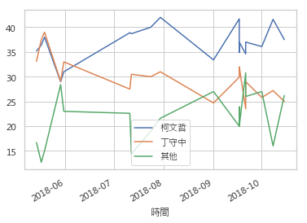

```python
taipei.iloc[:,[0,2,3]].plot()
```

```
Text(0,0.5,'支持率')
```

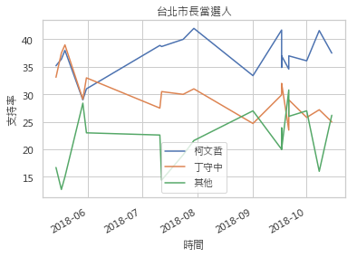

```python
ax = taipei.iloc[:,[0,2,3]].plot()
ax.set_title('台北市長當選人')
ax.set_ylabel('支持率')
```

## Exercises and Solutions

**1. 從 `polls` 選出 `訪問主題` 為 `高雄市長當選人` 的表格**

```python kaohsiung = polls[polls['訪問主題'] == '高雄市長當選人'] ```

**2. 從 1. 得到的表格中，將 `支持率` 轉變為一個新的表格 (提示 `apply`)**

```python percentage = kaohsiung['支持率'].apply(pd.Series) ```

**3. 將 2. 得到的表格中，把每格的百分比轉為 `float` (提示 `applymap`)**

```python percentage = percentage.applymap(lambda x: float(x.strip('%'))) ```

**4. 將 1. 和 3. 得到的表格合併**

```python kaohsiung = pd.concat([percentage, kaohsiung.iloc[:,1:]], axis=1) ```

**5. 設定 4. 的表格的 `index` 為 `時間`**

```python kaohsiung = kaohsiung.set_index('時間') ```

**6. 選取 `2018-08-01` 之後的表格**

```python kaohsiung = kaohsiung.loc[kaohsiung.index > "2018-08-01"] ```

**7. 畫出兩位候選人隨著時間的支持度變化**

```python ax = kaohsiung.iloc[:,[0,1]].plot() ```